# Airborne data files

- L1 reflectance data are saved on network drive in `DATA/L1-reflectance2`
- `spectra` folder contains separate files with reflectance values
- `meta` folder contains separate files for each flightline file with metadata

in metadata:

- nmdLctn and loctype (eg. PRLA.AOS.buoy.c0)
- sensor_zenith (degrees) - varies by pixel
- solar_zenith (degrees) - same for entire flightline
- clouds - same for entire flightline

The time of the pixel acquition is saved in the meta radiance info. The radiance metadata data frame is all of the flightlines for that year, filtered to preferred location. May include NA areas. Match to reflectance data using pixel location (cellrow, cellcol)

Take the interpolated spectra and estimate above water remote sensing reflectance (with and without effects of solar zenith angle) as well as below water remote sensing reflectence. The remote sensing reflectance spectra should be more copmarable? but maybe would still need to be normalized. Effects of glint are not accounted for.

```r
mysite = 'PRLA'
my_aop_yr = '2020'
my_loc = pref_locs %>% dplyr::filter(siteID %in% mysite) %>% pull(namedLocation)
my_loc
```

```
## [1] "PRLA.AOS.buoy.c0"
```

```r
my_spectra_fileIDs <- str_detect(spectra_files, glue::glue('{mysite}.*({my_aop_yr})'))
flightlines <- basename(spectra_files[my_spectra_fileIDs]) %>%
  purrr::map(~str_split(.x, pattern = "_", simplify = TRUE)[6:7]) %>%
  purrr::map_chr(~glue('{.x[[1]]}_{.x[[2]]}'))
flightlines
```

```
## [1] "20200624_161319" "20200624_162051" "20200624_162804" "20200624_173036"
## [5] "20200626_192243" "20200702_171105"
```

For each flightline, check if there is data then plot

```r
fl_plots <- map(flightlines, ~process_flightline_refl(.x))
```

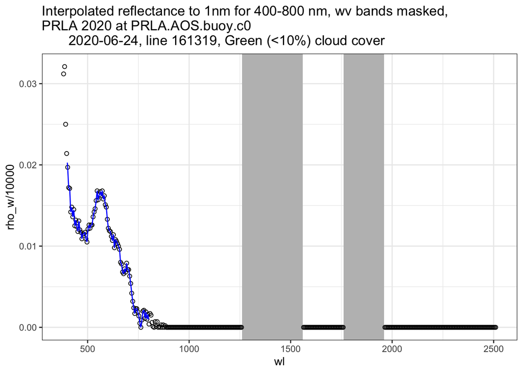

```r
# process_flightline_refl(flightlines[3])
fl_plots[[1]]$plot1
```

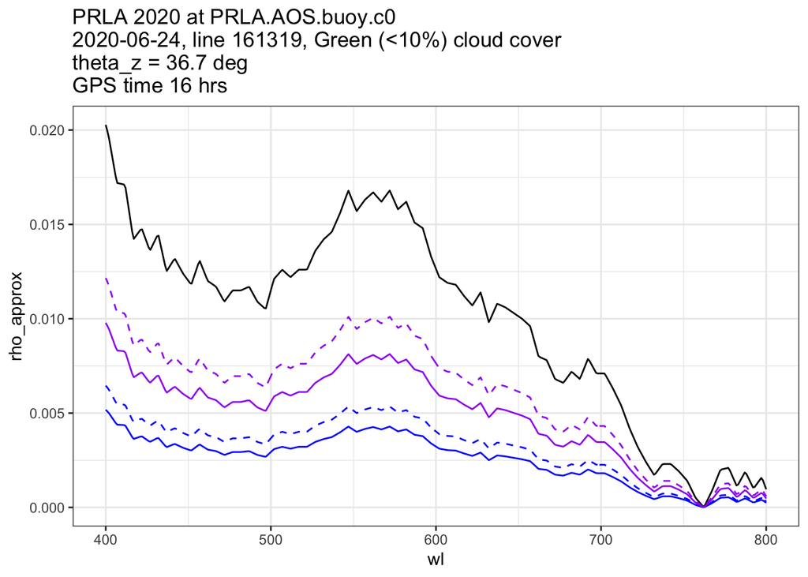

```r
fl_plots[[1]]$plot2
```

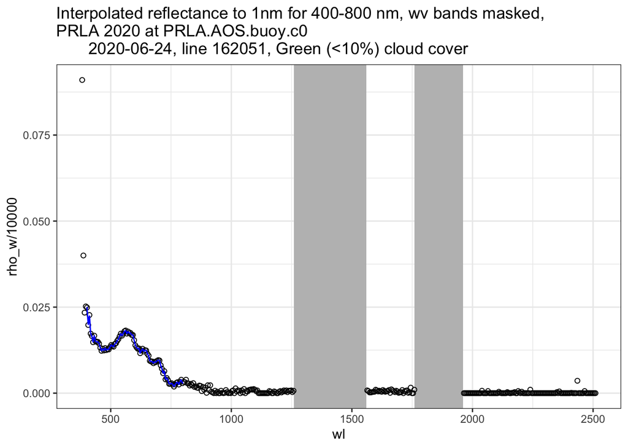

```r
fl_plots[[2]]$plot1
```

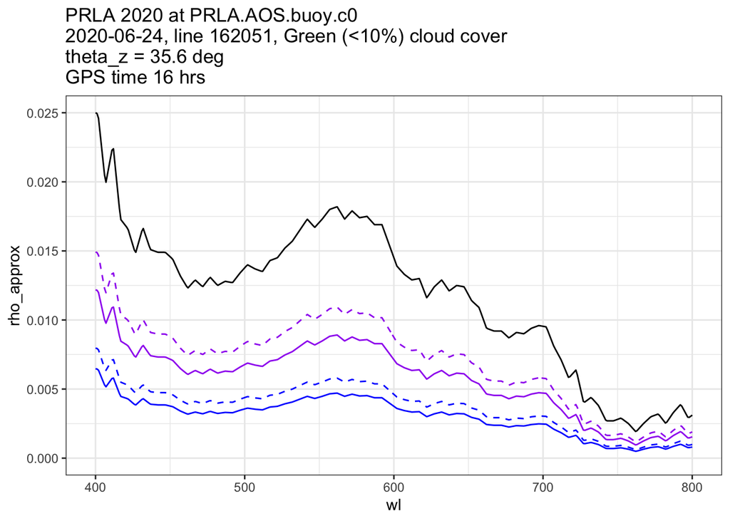

```r
fl_plots[[2]]$plot2
```

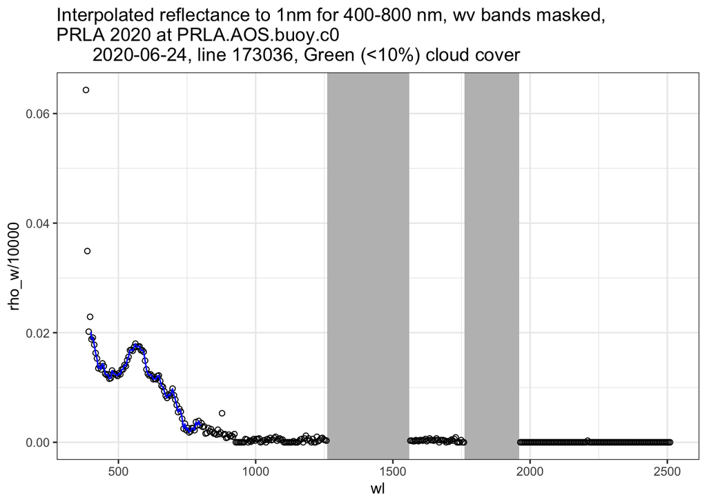

```r
fl_plots[[4]]$plot1
```

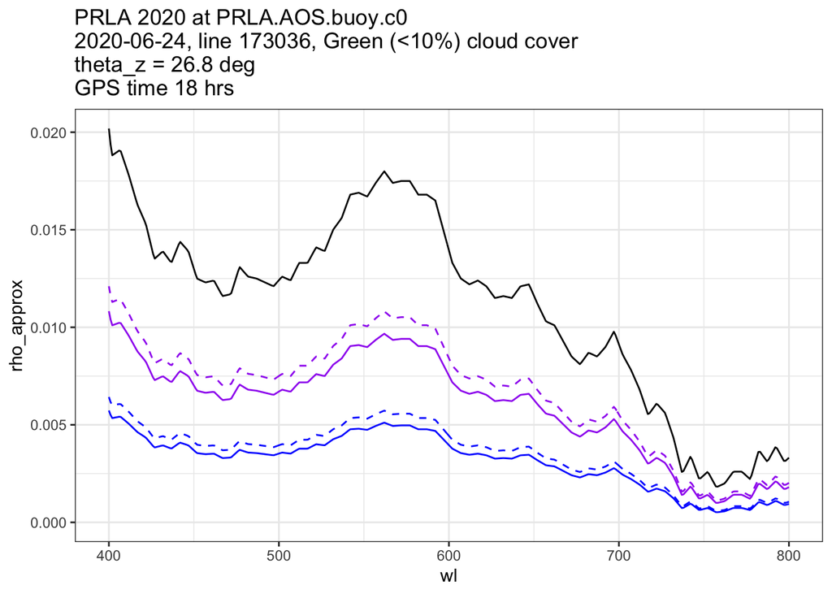

```r
fl_plots[[4]]$plot2
```

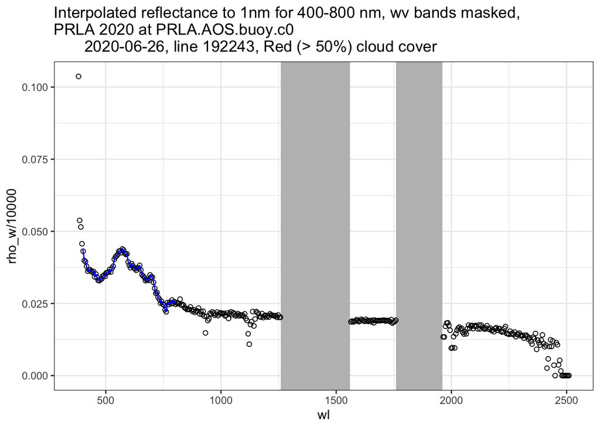

```r
fl_plots[[5]]$plot1
```

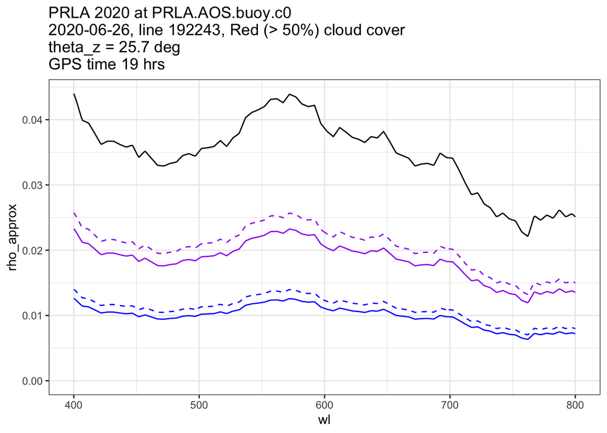

```r
fl_plots[[5]]$plot2
```

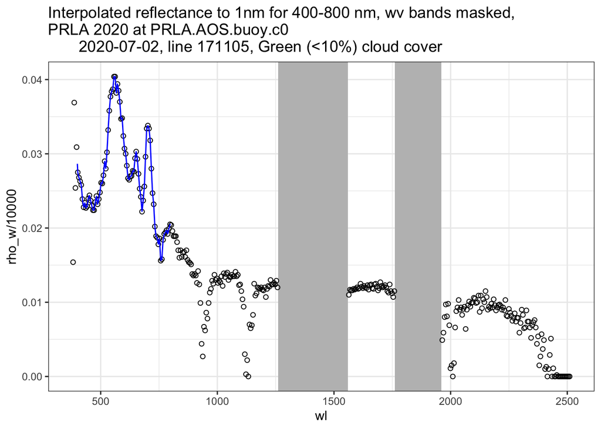

```r
fl_plots[[6]]$plot1
```

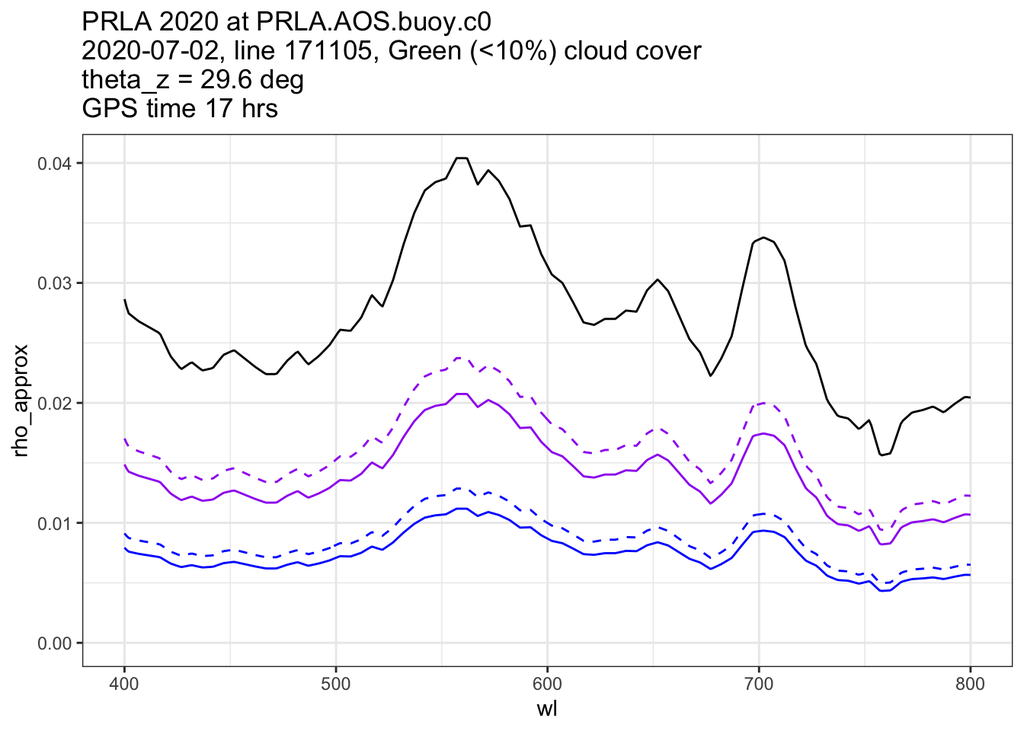

```r
fl_plots[[6]]$plot2
```

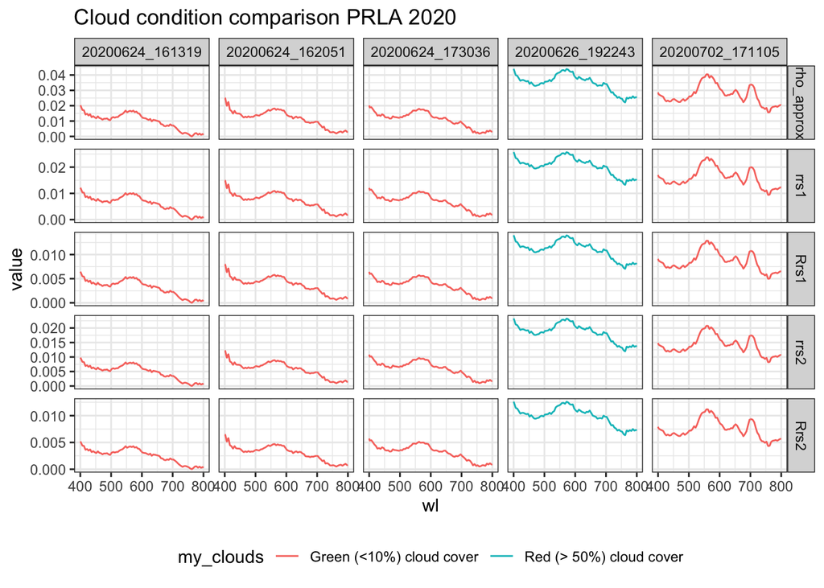

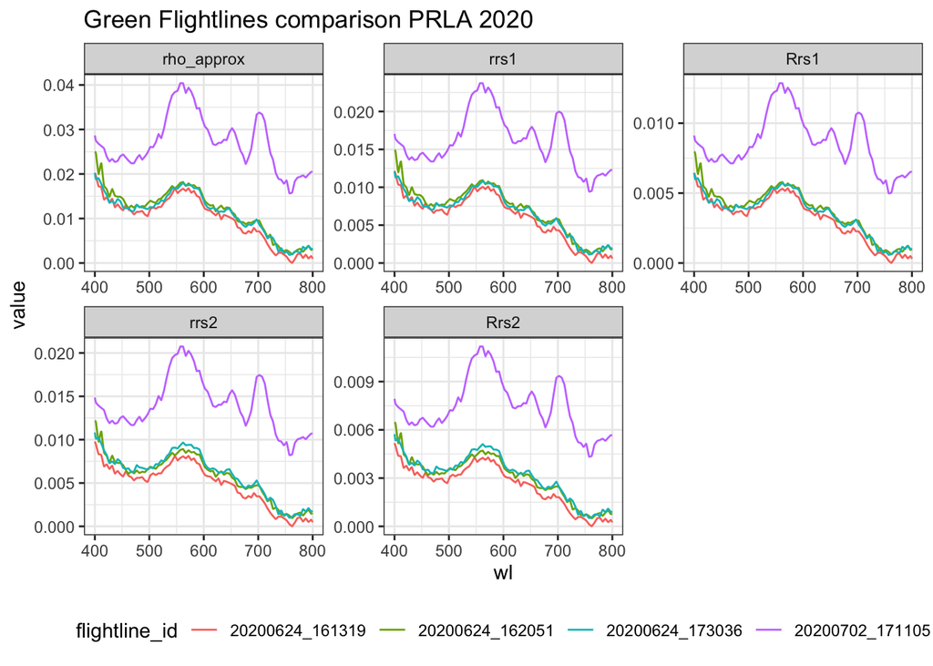

| flightline_id | my_theta | my_gpstime_hrs |
| --- | --- | --- |
| 20200624_161319 | 36.73749 | 16.31230 |
| 20200624_162051 | 35.64215 | 16.43769 |
| 20200624_173036 | 26.83384 | 17.60777 |
| 20200702_171105 | 29.60470 | 17.23627 |

```r
fl_data <- fl_plots %>% map(~.x[['data']])
names(fl_data) <- flightlines
fl_data_df <- bind_rows(fl_data, .id = 'flightline_id')
fl_data_long <- fl_data_df %>% tidyr::pivot_longer(cols = c(rho_approx, Rrs1, Rrs2, rrs1, rrs2))
fl_data_long_green <- fl_data_long %>% dplyr::filter(my_clouds %in% c('Green (<10%) cloud cover'))
```